# ACS Data & Mapping

# Mapping ACS variables

Yesterday Dr. Holmes and Dr. Stewart showed you how to pull data from the Census Bureau. In this example I am going to be pulling data from multiple counties in VA along with their geography. I will then explore how to map the variables you have pulled in a basic accessible map.

Once you have downloaded your ACS data, you can use the plot function to quickly map your variable of interest. Recall the data has one variable and the value is stored in the variable `estimate`.

```r
head(VA_income)
```

```
## Simple feature collection with 5 features and 5 fields
## Geometry type: MULTIPOLYGON
## Dimension:     XY
## Bounding box:  xmin: -78.13205 ymin: 37.41483 xmax: -77.6554 ymax: 37.69166
## Geodetic CRS:  NAD83
##         GEOID                                            NAME
## 1 51145500200    Census Tract 5002, Powhatan County, Virginia
## 2 51145500102 Census Tract 5001.02, Powhatan County, Virginia
## 3 51145500101 Census Tract 5001.01, Powhatan County, Virginia
## 4 51145500300    Census Tract 5003, Powhatan County, Virginia
## 5 51145500400    Census Tract 5004, Powhatan County, Virginia
##                  variable estimate   moe                       geometry
## 1 median.household.income    86469  9294 MULTIPOLYGON (((-77.96564 3...
## 2 median.household.income    97596  9668 MULTIPOLYGON (((-77.89829 3...
## 3 median.household.income    98906  7471 MULTIPOLYGON (((-77.8513 37...
## 4 median.household.income    93438 38203 MULTIPOLYGON (((-77.94981 3...
## 5 median.household.income    71004  9647 MULTIPOLYGON (((-78.13205 3...
```

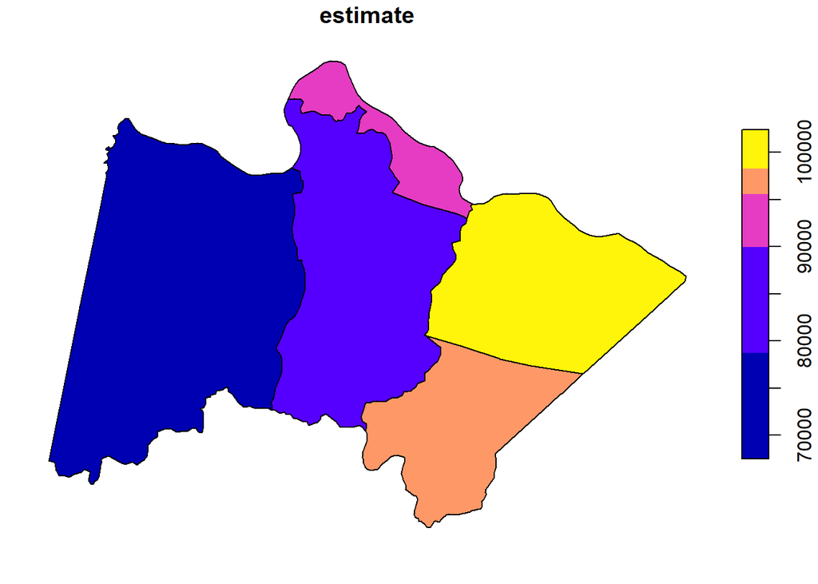

```r
plot(VA_income["estimate"]) #quick plot
```

## Using ggplot to map

The `ggplot2` package is also useful to drawing maps. In the code chunk below I use the `VA_income` dataset to show you how to draw a simple map with the `ggplot()` function in this package.

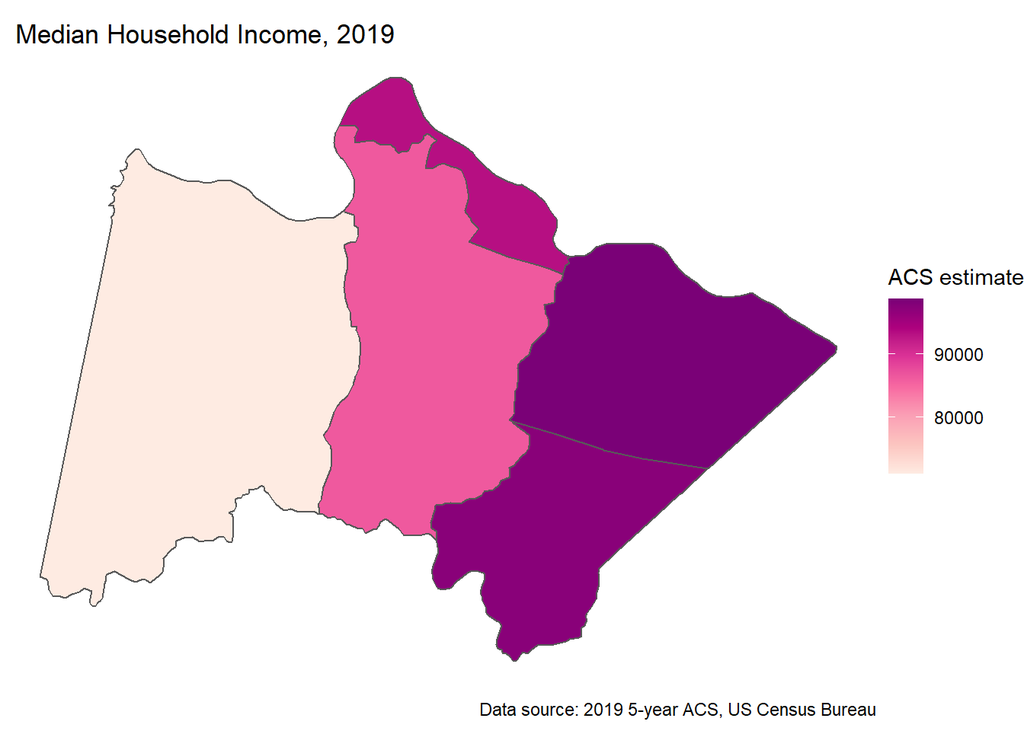

```r
library(ggplot2)
ggplot(data = VA_income, aes(fill = estimate)) + geom_sf() + scale_fill_distiller(palette = "RdPu", direction = 1) + labs(title = "  Median Household Income, 2019",
       caption = "Data source: 2019 5-year ACS, US Census Bureau",
       fill = "ACS estimate") +
  theme_void()  #Better plot
```

## Multiple ACS variables and maps

If you have a list of variables you need then you can modify the above code chunk to allow a list of variables that you place in a vector. Below you see my variable names are in the row vector:

```
c(population = "B02001_001",
median.gross.rent = "B25064_001",
median.household.income = "B19013_001",
rent.burden = "B25071_001",
white = "B03002_003",
af.am = "B03002_004",
hispanic = "B03002_012",
am.ind = "B03002_005",
asian = "B03002_006",
nh.pi = "B03002_007",
multiple = "B03002_009",
other = "B03002_008")
```

I feed this vector to `variables = c(...)` see below chunk.

```r
## Names for variable types
# Gives five year estimates
# To get Goochland County you will need to change Powhatan to Goochland
ACS5.2019 <- get_acs(geography = "tract", year=this.year,
                  state = "VA", county = c("Powhatan","Goochland"), geometry = TRUE,
                  variables = c(population = "B02001_001",
                                median.gross.rent = "B25064_001",
                                median.household.income = "B19013_001",
                                rent.burden = "B25071_001",
                                white = "B03002_003",
                                af.am = "B03002_004",
                                hispanic = "B03002_012",
                                am.ind = "B03002_005",
                                asian = "B03002_006",
                                nh.pi = "B03002_007",
                                multiple = "B03002_009",
                                other = "B03002_008"))
head(ACS5.2019)
```

```
## Simple feature collection with 6 features and 5 fields
## Geometry type: MULTIPOLYGON
## Dimension:     XY
## Bounding box:  xmin: -77.96564 ymin: 37.47227 xmax: -77.81921 ymax: 37.66908
## Geodetic CRS:  NAD83
##         GEOID                                         NAME   variable estimate
## 1 51145500200 Census Tract 5002, Powhatan County, Virginia population     8933
## 2 51145500200 Census Tract 5002, Powhatan County, Virginia      white     8288
## 3 51145500200 Census Tract 5002, Powhatan County, Virginia      af.am      317
## 4 51145500200 Census Tract 5002, Powhatan County, Virginia     am.ind       12
## 5 51145500200 Census Tract 5002, Powhatan County, Virginia      asian       29
## 6 51145500200 Census Tract 5002, Powhatan County, Virginia      nh.pi        0
##   moe                       geometry
## 1 405 MULTIPOLYGON (((-77.96564 3...
## 2 424 MULTIPOLYGON (((-77.96564 3...
## 3 157 MULTIPOLYGON (((-77.96564 3...
## 4  20 MULTIPOLYGON (((-77.96564 3...
## 5  29 MULTIPOLYGON (((-77.96564 3...
## 6  17 MULTIPOLYGON (((-77.96564 3...
```

Now that I have read in all the variables I will need to use the `dplyr` package to filter only the ones that I want to map.

## Put ACS data on a map

```r
library(dplyr)
```

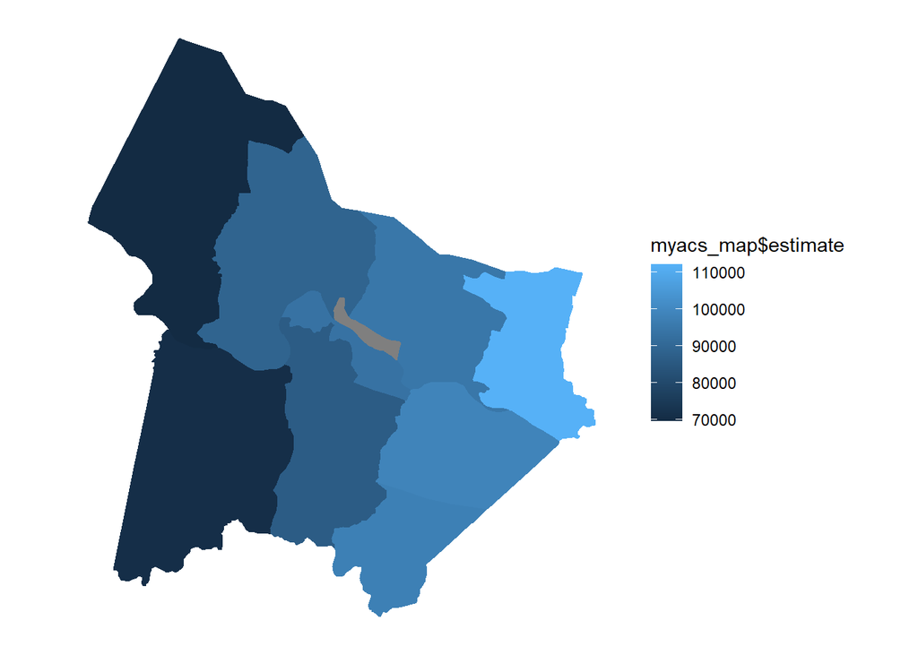

```r
myacs_map <- filter(ACS5.2019, variable == "median.household.income")

zap <- ggplot(myacs_map$geometry) +
    geom_sf(aes(fill=myacs_map$estimate, color = myacs_map$estimate)) +
    coord_sf(datum = NA) +
    theme_minimal()
zap
```

### Colorblind Friendly packages

The `viridis` package is a color blind friendly palatte. The options for this package are" “viridis”, “magma”, “inferno”, or “plasma”.

```r
# Create a colorblind friendly palette.
library(viridis)
```

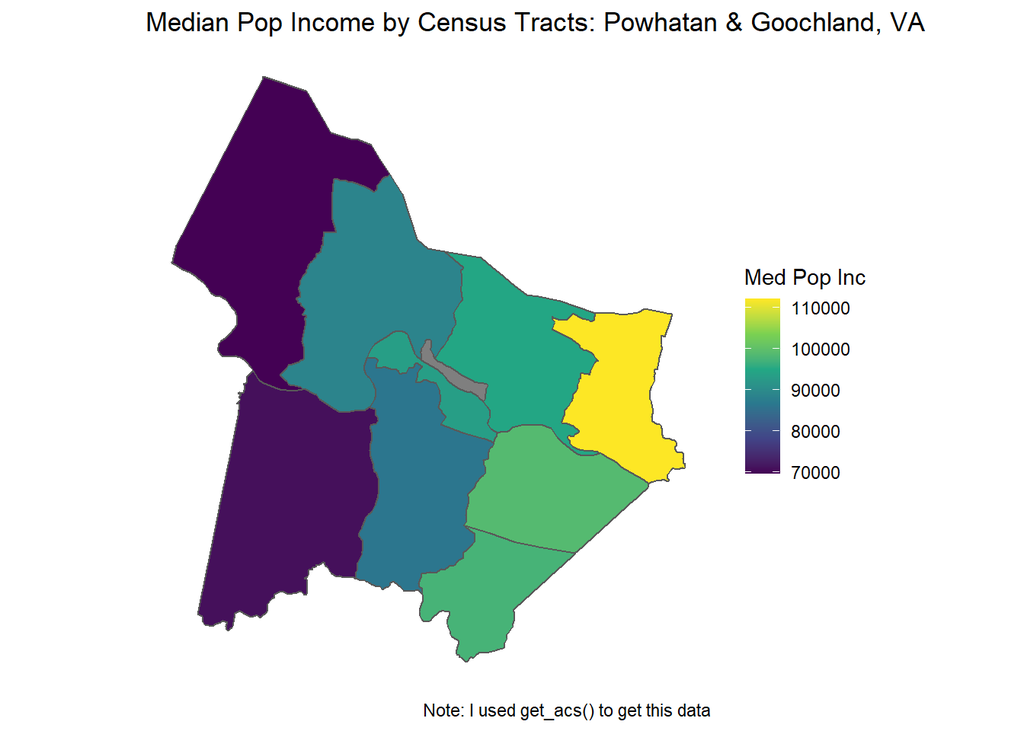

```r
zap2 <- ggplot(myacs_map$geometry) + geom_sf(aes(fill=myacs_map$estimate)) +
    scale_color_viridis_c() + scale_fill_viridis_c()+
    coord_sf(datum = NA) +
    theme_minimal() +
  labs(fill = "Med Pop Inc",
       title = "Median Pop Income by Census Tracts: Powhatan & Goochland, VA",
       caption = "Note: I used get_acs() to get this data")
zap2
```

## State Borders

```
## To enable
## caching of data, set `options(tigris_use_cache = TRUE)` in your R script or .Rprofile.
```

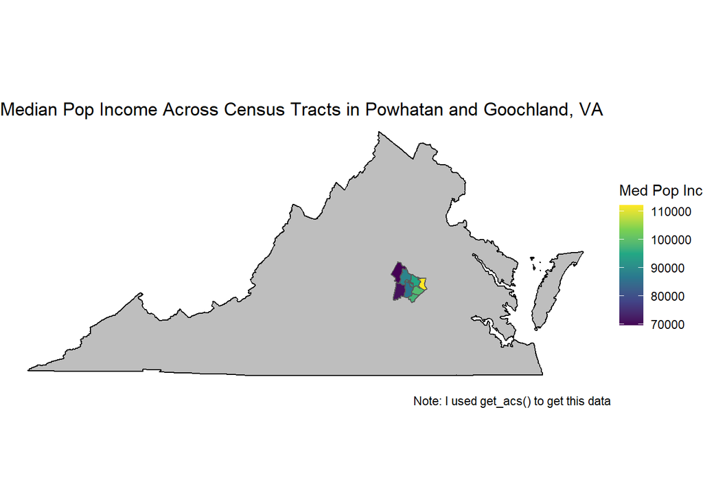

These maps are UGLY! You can do better !

# Saving and Exporting the R dataframe

At this point I would like to export my data to my hard drive. This is helpful if you plan to use it in RShiny apps. Here is how you save the data as an R dataframe.

```r
save(ACS5.2019,file="ACS5.2019.Rda")
```

In another R script you can load the data that you saved above

```r
load("ACS5.2019.Rda")
```

# Leaflet Package for Making Interactive Maps in R

Now we are going to use the `leaflet` package to produce maps. This only works well and is interactive in an html file. In the code chunk below I first declare a color palette that will be defined using the colorNumeric() function. This function itself creates a function we are calling mypal(), which translates data values to color values for a given color palette. Our chosen color palette in this example is the viridis magma palette.

```r
# Creating a map with leaflet
library(leaflet)
mypal <- colorNumeric(
  palette = "magma",
  domain = myacs_map$estimate
)

mypal(c(10, 20, 30, 40, 50))
```

```
## [1] "#808080" "#808080" "#808080" "#808080" "#808080"
```

```r
leaflet() %>%
  addProviderTiles(providers$Stamen.TonerLite) %>%
  addPolygons(data = myacs_map,
              color = ~mypal(estimate),
              weight = 0.5,
              smoothFactor = 0.2,
              fillOpacity = 0.5,
              label = ~estimate) %>%
  addLegend(
    position = "bottomright",
    pal = mypal,
    values = myacs_map$estimate,
    title = "Median Population Income Across VA Counties"
  )
```

[interactive chart not shown]

I used [this website as a reference document for my maps:](https://walker-data.com/census-r/mapping-census-data-with-r.html)

```r
#specify the bin breaks
mybins <- c(0,10000,20000,30000,40000,50000,60000,70000)
#specify the default color
mypalette <- colorBin(palette="inferno", domain=myacs_map$estimate, na.color="transparent", bins=mybins)

leaflet(data = myacs_map) %>%
  addTiles() %>%
  addPolygons(
    fillColor = ~mypalette(myacs_map$`estimate`),
    stroke=TRUE,
    weight = 1,
    smoothFactor = 0.2,
    opacity = 1.0,
    fillOpacity = 0.7,
    label=paste("County: ",myacs_map$GEOID, ", Value: ",myacs_map$estimate),
    highlightOptions = highlightOptions(color = "white",
                                        weight = 2,
                                        bringToFront = TRUE)) %>%
  addLegend(pal=mypalette, position = "bottomright",
            values = ~myacs_map$estimate,
            opacity = 0.5, title = "Median Population Income") %>%
  addPolylines(data = myacs_map, color = "black",
               opacity = 0.2, weight = 1)
```

[interactive chart not shown]

2. Or a different way to draw the map with a different baselayer.

```r
pal <- colorNumeric(
  palette = "inferno",
  domain = myacs_map$estimate
)
map4<-leaflet() %>%
  addProviderTiles("CartoDB.Positron") %>%
  addPolygons(data = myacs_map,
              fillColor = ~mypal(estimate),
              color = "#b2aeae", # you need to use hex colors
              fillOpacity = 0.7,
              weight = 1,
              smoothFactor = 0.2) %>%
  addLegend(pal = mypal,
            values = myacs_map$estimate,
            position = "bottomright",
            title = "Median Income")
map4
```

[interactive chart not shown]

# What we learned today:

1. We reviewed how to get ACS data again
2. We learned how to map ACS data in R using plot
3. We learned how to map ACS data in R using ggplot
4. We learned how to map ACS data in R using leaflet

# For your practice

Use ggplot2 and leaflet to draw a map of the county where you currently reside. Make a plot of census tract level median gross rent and another map of population